# 구글 콜래보래토리 소개

"Google Colaboratory = Google Drive + Juputer Noteook"

[figure not shown]

### 2017 http://financedata.kr

# Google Colaboratory

구글이 내부에서 사용하던 주피터 노트북 구글 커스텀 버전 (2017년 10월 공개)

한줄로 요약하자면,

**"Google Colaboratory = Google Drive + Juputer Noteook"**

# 간단한 소개

https://colab.research.google.com (접속하면 바로 소개문서 노트북)

1. Jupyter Notebook 기능 포함 (파이썬 실행, 마크다운, 수식, 차트 표현 등)
2. 구글 드라이브의 문서 생성과 공유 기능 (닥스 문서와 동일한 방법으로 생성, 공유)

(코드 실행에 필요한 커널이 연결이 안되지만, 사용 요청하면 하루 정도후에 승인)

# 실행 환경

```python
# 파이썬 버전

import sys
sys.version_info
```

```
sys.version_info(major=2, minor=7, micro=12, releaselevel='final', serial=0)
```

파이썬 버전 2.7이며 아직 파이썬3 이나 R, Julia등 다른 커널은 제공하지 않는다

```python
# OS 플랫폼

import platform
platform.platform()
```

```
'Linux-4.4.70+-x86_64-with-Ubuntu-16.04-xenial'
```

64비트 우분투 16.04 버전

```python
# 설치된 파이썬 패키지

import pip
pip.get_installed_distributions()
```

[output not shown]

[output cut: 48 more lines]

[output not shown]

scipy, numpy, pandas 등 대부분의 파이썬 패키지들이 설치되어 있으며, scikit-learn, tensorflow 등 머신러닝라이브러리도 설치되어 있다.

# 간단한 차트

```python
import numpy as np

data = np.random.randint(-100, 100, 50)
data
```

```
array([-91, -70, -40,  -1,  80, -76,  24,  45,  42,  83,  67, -15,  38,
        30,  85,  23,  -6,  30, -62, -21, -83,  61,  36, -26, -32,  99,
        78,  66,  78,  -4, -39,  11, -84,  63, -20, -17,  94,  88, -66,
       -62,  58,   6,  72, -86, -35, -46, -80, -19,  84,  37])
```

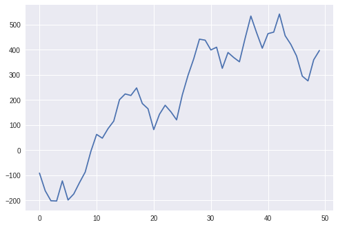

```python
import matplotlib.pyplot as plt

plt.plot(data.cumsum())
plt.show()
```

# 추가 패키지 설치

필요한 패키지가 설치되어 있지 않다면 pip 외부 명령으로 추가 설치할 수 있다.

```python
! pip install pandas_datareader
```

```
  Using cached pandas_datareader-0.5.0-py2.py3-none-any.whl
```

# 주가 데이터

pandas_datareader 와 pandas.DataFrame() 사용 예

```python
import pandas_datareader as pdr

# 삼성전자 1~3분기 가격 데이터
df = pdr.get_data_yahoo('005930.KS', '2017-01-01', '2017-09-30')

print('row count:', len(df))
df.tail(10)
```

```
('row count:', 185)
```

| Date | Open | High | Low | Close | Adj Close | Volume |
| --- | --- | --- | --- | --- | --- | --- |
| 2017-09-15 | 2515000.0 | 2528000.0 | 2493000.0 | 2520000.0 | 2520000.0 | 215146 |
| 2017-09-18 | 2527000.0 | 2624000.0 | 2526000.0 | 2624000.0 | 2624000.0 | 230499 |
| 2017-09-19 | 2625000.0 | 2632000.0 | 2589000.0 | 2606000.0 | 2606000.0 | 197008 |
| 2017-09-20 | 2606000.0 | 2625000.0 | 2592000.0 | 2611000.0 | 2611000.0 | 185855 |
| 2017-09-21 | 2611000.0 | 2648000.0 | 2611000.0 | 2640000.0 | 2640000.0 | 176796 |
| 2017-09-25 | 2648000.0 | 2684000.0 | 2623000.0 | 2681000.0 | 2681000.0 | 464510 |
| 2017-09-26 | 2681000.0 | 2681000.0 | 2681000.0 | 2681000.0 | 2681000.0 | 0 |
| 2017-09-27 | 2600000.0 | 2610000.0 | 2575000.0 | 2584000.0 | 2584000.0 | 215940 |
| 2017-09-28 | 2613000.0 | 2623000.0 | 2563000.0 | 2563000.0 | 2563000.0 | 240509 |
| 2017-09-29 | 2559000.0 | 2581000.0 | 2542000.0 | 2564000.0 | 2564000.0 | 258188 |

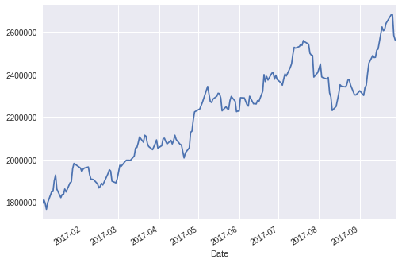

```python
# 삼성전자 2017년 1~3분기 수정종가 차트

df['Adj Close'].plot()
```

# 결론

(다른 구글닥스의 문서와 마찬가지로) 주피터 노트북 문서를 여러 사람이 동시에 열어서 함께 편집하는 것이 가능하다.

따로 설치한 주피터 노트북보다 더 많은 기능이 있다고할 수 없으나 Google Drive의 공유와 동시 편집기능은 협업에 매우 유용하다.

※ 본 문서 자체가 구글 드라이브에서 생성하고 작성한 문서입니다. 고유링크: https://colab.research.google.com/notebook#fileId=0B2Op0f7i-jUEem1NUWVaRDlwVVE

### 2017 http://financedata.kr